# Assignment 2

Manning Smith

9/22/2024

# Part 1

The C-statistics, or the Area Under the ROC curve, is the probability that a classifier will be more confident that a randomly chosen positive example is actually positive than that a randomly chosen negative example is positive.

**a) What is the range of the C-statistics (AUC or the area under the ROC curves?**  
The range is from 0 to 1 for the c-statistic.

**b) What does mean if C-statistics (AUC)=0.5?**  
This aligns with that of being a situation of random guessing/random classification, showing no statistical evidence.

**c) What does mean if C-statistics (AUC)=1?**  
This align with that of suggesting that there is statistical evidence of perfect classification.

# Import Data

```r
Heart <- read.csv("Heart.csv")
Heart <- na.omit(Heart)

#View(Heart)
```

# Data Set Information

- PatientID: unique patient identifier
- Age: age in years
- Sex: 1 = male; 0 = female
- ChestPain: chest pain type
- RestBP: resting blood pressure (in mm Hg on admission to the hospital)
- Chol: serum cholestoral in mg/dl
- Fbs: fasting blood sugar > 120 mg/dl (1 = true; 0 = false)
- RestECG: resting electrocardiographic results. 0: normal ; 1: having ST-T wave abnormality (T wave inversions and/or ST elevation or depression of > 0.05 mV) ; 2: showing probable or definite left ventricular hypertrophy by Estes’ criteria.
- MaxHR: maximum heart rate achieved
- ExAng: exercise induced angina (1 = yes; 0 = no)
- Oldpeak: ST depression induced by exercise relative to rest
- Slope: the slope of the peak exercise ST segment. 1: upsloping; 2: flat; 3: downsloping
- Ca: number of major vessels (0-3) colored by flourosopy
- Thal: Thallium stress test, 3 =normal; 6 = fixed (defect); 7 = reversable (defect)
- AHD (the predicted attribute): angiographic heart disease

# Part 2

This part involves the Heart.csv, with which you worked in assignment #1. Please submit your work with corresponding R/Python codes.

## Question 1 | We try to predict RestBP (resting blood pressure, in mm Hg on admission to the hospital), using other variables in the data set; i.e; RestBP is the response (outcome) , and other variables are the predictors.

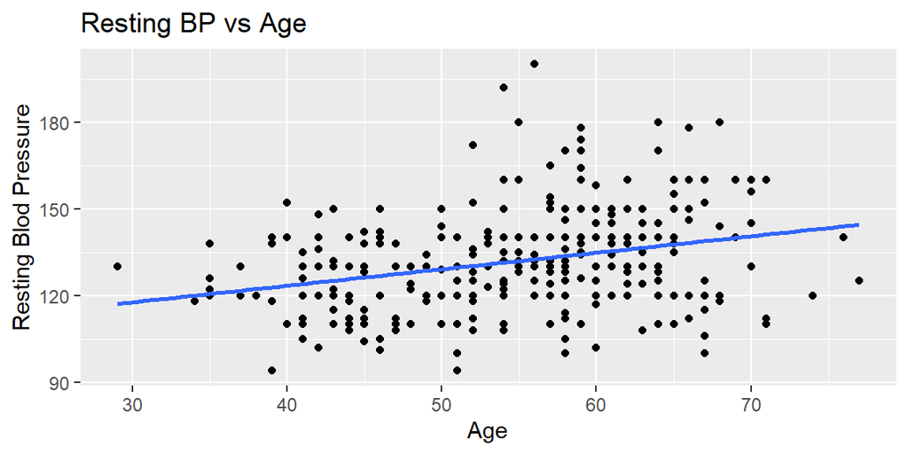

```r
ggplot(Heart, aes(x = Age, y = RestBP)) +
  geom_point() +
  labs(x = "Age", y = "Resting Blod Pressure", title = "Resting BP vs Age") +
  geom_smooth(method = "lm", se = FALSE)
```

### 1a) For each variable, fit a simple linear regression model to predict the response. Describe your results. In which of the models is there a statistically significant association between the predictor and the response?

```r
# 1. Simple linear regression with Age
model_age <- lm(RestBP ~ Age, data = Heart)
print(summary(model_age))
```

```
##
## Call:
## lm(formula = RestBP ~ Age, data = Heart)
##
## Residuals:
##     Min      1Q  Median      3Q     Max
## -38.796 -11.946  -0.814  10.326  67.475
##
## Coefficients:
##             Estimate Std. Error t value Pr(>|t|)
## (Intercept) 100.5966     6.0455  16.640  < 2e-16 ***
## Age           0.5701     0.1094   5.214 3.48e-07 ***
## ---
## Signif. codes:  0 '***' 0.001 '**' 0.01 '*' 0.05 '.' 0.1 ' ' 1
##
## Residual standard error: 17.03 on 295 degrees of freedom
## Multiple R-squared:  0.08438,    Adjusted R-squared:  0.08127
## F-statistic: 27.18 on 1 and 295 DF,  p-value: 3.485e-07
```

```r
# 2. Simple linear regression with Sex
model_sex <- lm(RestBP ~ Sex, data = Heart)
print(summary(model_sex))
```

```
##
## Call:
## lm(formula = RestBP ~ Sex, data = Heart)
##
## Residuals:
##     Min      1Q  Median      3Q     Max
## -39.396 -10.881  -0.881   9.119  66.604
##
## Coefficients:
##             Estimate Std. Error t value Pr(>|t|)
## (Intercept)  133.396      1.812  73.619   <2e-16 ***
## Sex           -2.515      2.203  -1.142    0.254
## ---
## Signif. codes:  0 '***' 0.001 '**' 0.01 '*' 0.05 '.' 0.1 ' ' 1
##
## Residual standard error: 17.75 on 295 degrees of freedom
## Multiple R-squared:  0.004401,   Adjusted R-squared:  0.001026
## F-statistic: 1.304 on 1 and 295 DF,  p-value: 0.2544
```

```r
# 3. Simple linear regression with ChestPain
model_chestpain <- lm(RestBP ~ ChestPain, data = Heart)
print(summary(model_chestpain))
```

```
##
## Call:
## lm(formula = RestBP ~ ChestPain, data = Heart)
##
## Residuals:
##     Min      1Q  Median      3Q     Max
## -36.133 -12.133  -0.469   9.768  67.768
##
## Coefficients:
##                     Estimate Std. Error t value Pr(>|t|)
## (Intercept)          132.232      1.477  89.558   <2e-16 ***
## ChestPainnonanginal   -2.100      2.431  -0.864   0.3884
## ChestPainnontypical   -3.763      2.915  -1.291   0.1978
## ChestPaintypical       8.637      3.955   2.184   0.0298 *
## ---
## Signif. codes:  0 '***' 0.001 '**' 0.01 '*' 0.05 '.' 0.1 ' ' 1
##
## Residual standard error: 17.59 on 293 degrees of freedom
## Multiple R-squared:  0.0288, Adjusted R-squared:  0.01885
## F-statistic: 2.896 on 3 and 293 DF,  p-value: 0.03549
```

```r
# 4. Simple linear regression with Chol
model_chol <- lm(RestBP ~ Chol, data = Heart)
print(summary(model_chol))
```

```
##
## Call:
## lm(formula = RestBP ~ Chol, data = Heart)
##
## Residuals:
##     Min      1Q  Median      3Q     Max
## -36.779 -11.363  -1.992   9.962  66.480
##
## Coefficients:
##              Estimate Std. Error t value Pr(>|t|)
## (Intercept) 120.57925    4.98309  24.198   <2e-16 ***
## Chol          0.04493    0.01972   2.279   0.0234 *
## ---
## Signif. codes:  0 '***' 0.001 '**' 0.01 '*' 0.05 '.' 0.1 ' ' 1
##
## Residual standard error: 17.64 on 295 degrees of freedom
## Multiple R-squared:  0.0173, Adjusted R-squared:  0.01397
## F-statistic: 5.194 on 1 and 295 DF,  p-value: 0.02338
```

```r
# 5. Simple linear regression with Fbs
model_fbs <- lm(RestBP ~ Fbs, data = Heart)
print(summary(model_fbs))
```

```
##
## Call:
## lm(formula = RestBP ~ Fbs, data = Heart)
##
## Residuals:
##     Min      1Q  Median      3Q     Max
## -38.488 -10.374  -0.374   9.626  61.626
##
## Coefficients:
##             Estimate Std. Error t value Pr(>|t|)
## (Intercept)  130.374      1.098 118.736  < 2e-16 ***
## Fbs            9.114      2.886   3.158  0.00175 **
## ---
## Signif. codes:  0 '***' 0.001 '**' 0.01 '*' 0.05 '.' 0.1 ' ' 1
##
## Residual standard error: 17.5 on 295 degrees of freedom
## Multiple R-squared:  0.03271,    Adjusted R-squared:  0.02943
## F-statistic: 9.976 on 1 and 295 DF,  p-value: 0.001751
```

```r
# 6. Simple linear regression with RestECG
model_restech <- lm(RestBP ~ RestECG, data = Heart)
print(summary(model_restech))
```

```
##
## Call:
## lm(formula = RestBP ~ RestECG, data = Heart)
##
## Residuals:
##     Min      1Q  Median      3Q     Max
## -35.038 -10.367  -2.367  10.633  65.633
##
## Coefficients:
##             Estimate Std. Error t value Pr(>|t|)
## (Intercept)  129.038      1.446  89.224   <2e-16 ***
## RestECG        2.665      1.028   2.592     0.01 *
## ---
## Signif. codes:  0 '***' 0.001 '**' 0.01 '*' 0.05 '.' 0.1 ' ' 1
##
## Residual standard error: 17.59 on 295 degrees of freedom
## Multiple R-squared:  0.02227,    Adjusted R-squared:  0.01896
## F-statistic:  6.72 on 1 and 295 DF,  p-value: 0.01001
```

```r
# 7. Simple linear regression with MaxHR
model_maxhr <- lm(RestBP ~ MaxHR, data = Heart)
print(summary(model_maxhr))
```

```
##
## Call:
## lm(formula = RestBP ~ MaxHR, data = Heart)
##
## Residuals:
##     Min      1Q  Median      3Q     Max
## -37.526 -11.907  -1.678   8.854  67.675
##
## Coefficients:
##              Estimate Std. Error t value Pr(>|t|)
## (Intercept) 137.38171    6.81418  20.161   <2e-16 ***
## MaxHR        -0.03802    0.04502  -0.844    0.399
## ---
## Signif. codes:  0 '***' 0.001 '**' 0.01 '*' 0.05 '.' 0.1 ' ' 1
##
## Residual standard error: 17.77 on 295 degrees of freedom
## Multiple R-squared:  0.002412,   Adjusted R-squared:  -0.0009701
## F-statistic: 0.7131 on 1 and 295 DF,  p-value: 0.3991
```

```r
# 8. Simple linear regression with ExAng
model_exang <- lm(RestBP ~ ExAng, data = Heart)
print(summary(model_exang))
```

```
##
## Call:
## lm(formula = RestBP ~ ExAng, data = Heart)
##
## Residuals:
##    Min     1Q Median     3Q    Max
## -39.39 -10.87  -0.87   9.13  66.61
##
## Coefficients:
##             Estimate Std. Error t value Pr(>|t|)
## (Intercept)  130.870      1.255 104.250   <2e-16 ***
## ExAng          2.522      2.197   1.148    0.252
## ---
## Signif. codes:  0 '***' 0.001 '**' 0.01 '*' 0.05 '.' 0.1 ' ' 1
##
## Residual standard error: 17.75 on 295 degrees of freedom
## Multiple R-squared:  0.004448,   Adjusted R-squared:  0.001073
## F-statistic: 1.318 on 1 and 295 DF,  p-value: 0.2519
```

```r
# 9. Simple linear regression with Oldpeak
model_oldpeak <- lm(RestBP ~ Oldpeak, data = Heart)
print(summary(model_oldpeak))
```

```
##
## Call:
## lm(formula = RestBP ~ Oldpeak, data = Heart)
##
## Residuals:
##     Min      1Q  Median      3Q     Max
## -34.619 -11.775  -1.106   9.633  63.381
##
## Coefficients:
##             Estimate Std. Error t value Pr(>|t|)
## (Intercept) 128.6187     1.3679  94.024  < 2e-16 ***
## Oldpeak       2.9131     0.8705   3.346 0.000924 ***
## ---
## Signif. codes:  0 '***' 0.001 '**' 0.01 '*' 0.05 '.' 0.1 ' ' 1
##
## Residual standard error: 17.46 on 295 degrees of freedom
## Multiple R-squared:  0.03657,    Adjusted R-squared:  0.03331
## F-statistic:  11.2 on 1 and 295 DF,  p-value: 0.0009245
```

```r
# 10. Simple linear regression with Slope
model_slope <- lm(RestBP ~ Slope, data = Heart)
print(summary(model_slope))
```

```
##
## Call:
## lm(formula = RestBP ~ Slope, data = Heart)
##
## Residuals:
##     Min      1Q  Median      3Q     Max
## -35.595 -13.077  -1.595  10.405  63.441
##
## Coefficients:
##             Estimate Std. Error t value Pr(>|t|)
## (Intercept)  126.113      2.852  44.220   <2e-16 ***
## Slope          3.482      1.661   2.097   0.0369 *
## ---
## Signif. codes:  0 '***' 0.001 '**' 0.01 '*' 0.05 '.' 0.1 ' ' 1
##
## Residual standard error: 17.66 on 295 degrees of freedom
## Multiple R-squared:  0.01468,    Adjusted R-squared:  0.01134
## F-statistic: 4.396 on 1 and 295 DF,  p-value: 0.03688
```

```r
# 11. Simple linear regression with Ca
model_ca <- lm(RestBP ~ Ca, data = Heart)
print(summary(model_ca))
```

```
##
## Call:
## lm(formula = RestBP ~ Ca, data = Heart)
##
## Residuals:
##    Min     1Q Median     3Q    Max
## -38.29 -10.44  -0.44   9.56  65.85
##
## Coefficients:
##             Estimate Std. Error t value Pr(>|t|)
## (Intercept)  130.440      1.267 102.928   <2e-16 ***
## Ca             1.853      1.096   1.691    0.092 .
## ---
## Signif. codes:  0 '***' 0.001 '**' 0.01 '*' 0.05 '.' 0.1 ' ' 1
##
## Residual standard error: 17.71 on 295 degrees of freedom
## Multiple R-squared:  0.009595,   Adjusted R-squared:  0.006238
## F-statistic: 2.858 on 1 and 295 DF,  p-value: 0.09198
```

```r
# 12. Simple linear regression with Thal
model_thal <- lm(RestBP ~ Thal, data = Heart)
print(summary(model_thal))
```

```
##
## Call:
## lm(formula = RestBP ~ Thal, data = Heart)
##
## Residuals:
##     Min      1Q  Median      3Q     Max
## -40.139 -11.402  -1.402  10.598  65.861
##
## Coefficients:
##                Estimate Std. Error t value Pr(>|t|)
## (Intercept)     136.944      4.155  32.961   <2e-16 ***
## Thalnormal       -7.542      4.377  -1.723   0.0859 .
## Thalreversable   -2.805      4.468  -0.628   0.5306
## ---
## Signif. codes:  0 '***' 0.001 '**' 0.01 '*' 0.05 '.' 0.1 ' ' 1
##
## Residual standard error: 17.63 on 294 degrees of freedom
## Multiple R-squared:  0.0219, Adjusted R-squared:  0.01524
## F-statistic: 3.291 on 2 and 294 DF,  p-value: 0.0386
```

**RestBP~Age**  
Age is a significant predictor RestBP, with an estimated increase of 0.57 mm Hg for each additional year of age. The p-value for the age coefficient is highly significant (p < 0.001).

**RestBP~Sex**  
Sex is not a significant predictor of RestBP (p = 0.254). The R-squared value is extremely low (0.0044), suggesting that there is almost no relationship between sex and RestBP.

**RestBP~ChestPain**  
Chest pain type is a weak but significant predictor of RestBP (p = 0.035). Specifically, typical angina is associated with an 8.64 mm Hg increase in RestBP (p = 0.03).

**RestBP~Chol**  
holesterol (Chol) is a statistically significant predictor of RestBP (p = 0.023), with an estimated increase of 0.0449 mm Hg in RestBP for every 1 mg/dL increase in cholesterol.

**RestBP~Fbs**  
Fasting blood sugar (Fbs) is a significant predictor of RestBP (p = 0.00175), with an estimated increase of 9.11 mm Hg in RestBP for those with fasting blood sugar > 120 mg/dL.

**RestBP~RestECG**  
Resting ECG results are a weak but statistically significant predictor of RestBP (p = 0.01). Patients with abnormal RestECG results have an estimated increase of 2.67 mm Hg in RestBP. The R-squared value (2.23%) indicates that RestECG explains very little of the variance.

**RestBP~MaxHR**  
Maximum heart rate (MaxHR) is not a significant predictor of RestBP (p = 0.399). The R-squared value is extremely low (0.0024), meaning there is no meaningful relationship between MaxHR and RestBP.

**RestBP~ExAng**  
Exercise-induced angina (ExAng) is not a significant predictor of RestBP (p = 0.252). The R-squared value is low (0.0044), indicating that ExAng does not explain much of the variance in RestBP.

**RestBP~Oldpeak**  
ST depression induced by exercise (Oldpeak) is a significant predictor of RestBP (p = 0.000924). For each unit increase in Oldpeak, RestBP increases by 2.91 mm Hg.

**RestBP~Slope**  
The slope of the ST segment is a weak but significant predictor of RestBP (p = 0.0369), with an increase of 3.48 mm Hg for higher slope values.

**RestBP~Ca**  
The number of major vessels colored by fluoroscopy (Ca) is not a significant predictor of RestBP (p = 0.092), though it approaches significance.

**RestBP~Thal**  
Thallium stress test results (Thal) are marginally significant overall (p = 0.0386), but none of the specific categories are individually significant (p-values for Thal normal and reversible are both above 0.05).

In conclusion, most variables have weak relationships with RestBP, with low R-squared values across the board. Age, cholesterol, fasting blood sugar, RestECG, Oldpeak, and Slope are statistically significant, but none of the models explain much of the variance in RestBP, suggesting that RestBP is influenced by other unmodeled factors.

### 1b) Fit a multiple regression model to predict the response using all of the predictors. Describe your results. For which predictors can we reject the null hypothesis:

```r
MLG_model <- lm(RestBP ~ Age + Sex + ChestPain + Chol + Fbs + RestECG + MaxHR + ExAng + Oldpeak + Slope + Ca + Thal, data = Heart)

print(summary(MLG_model))
```

```
##
## Call:
## lm(formula = RestBP ~ Age + Sex + ChestPain + Chol + Fbs + RestECG +
##     MaxHR + ExAng + Oldpeak + Slope + Ca + Thal, data = Heart)
##
## Residuals:
##     Min      1Q  Median      3Q     Max
## -35.690 -10.046  -1.279   9.030  56.635
##
## Coefficients:
##                     Estimate Std. Error t value Pr(>|t|)
## (Intercept)         89.27932   13.98739   6.383 7.15e-10 ***
## Age                  0.51128    0.12619   4.052 6.59e-05 ***
## Sex                 -4.37090    2.33530  -1.872   0.0623 .
## ChestPainnonanginal -0.42224    2.62308  -0.161   0.8722
## ChestPainnontypical  0.93336    3.16081   0.295   0.7680
## ChestPaintypical     7.79019    3.95930   1.968   0.0501 .
## Chol                 0.01709    0.01973   0.866   0.3873
## Fbs                  6.93486    2.83123   2.449   0.0149 *
## RestECG              1.53271    1.00839   1.520   0.1296
## MaxHR                0.09563    0.05358   1.785   0.0754 .
## ExAng                1.35605    2.44086   0.556   0.5790
## Oldpeak              2.29760    1.09546   2.097   0.0369 *
## Slope               -0.71454    2.02738  -0.352   0.7248
## Ca                  -1.24678    1.19016  -1.048   0.2957
## Thalnormal          -7.35500    4.46879  -1.646   0.1009
## Thalreversable      -2.67292    4.27937  -0.625   0.5327
## ---
## Signif. codes:  0 '***' 0.001 '**' 0.01 '*' 0.05 '.' 0.1 ' ' 1
##
## Residual standard error: 16.49 on 281 degrees of freedom
## Multiple R-squared:  0.1815, Adjusted R-squared:  0.1378
## F-statistic: 4.153 on 15 and 281 DF,  p-value: 6.656e-07
```

Based on the results of the multiple regression that only results that we can say have enough significance with greater than 95% confidence are with the variables of age, fbs, and oldpeak. All other variables show no significance greater than 95%.

### 1c) Preform variable selection (model selection) via forward, backward selection, and step-wise selection method, and then choose the optimal model to predict the response. Use model selection criteria to justify your results.

```r
# 1. Backward Selection
backward_model <- step(MLG_model, direction = "backward", trace = 1)
```

```
## Start:  AIC=1680.53
## RestBP ~ Age + Sex + ChestPain + Chol + Fbs + RestECG + MaxHR +
##     ExAng + Oldpeak + Slope + Ca + Thal
##
##             Df Sum of Sq   RSS    AIC
## - Slope      1      33.8 76481 1678.7
## - ExAng      1      84.0 76531 1678.9
## - Chol       1     204.0 76651 1679.3
## - ChestPain  3    1248.9 77696 1679.3
## - Ca         1     298.6 76745 1679.7
## <none>                   76447 1680.5
## - RestECG    1     628.5 77075 1681.0
## - Thal       2    1297.2 77744 1681.5
## - MaxHR      1     866.6 77313 1681.9
## - Sex        1     953.0 77400 1682.2
## - Oldpeak    1    1196.8 77644 1683.2
## - Fbs        1    1632.2 78079 1684.8
## - Age        1    4465.8 80913 1695.4
##
## Step:  AIC=1678.67
## RestBP ~ Age + Sex + ChestPain + Chol + Fbs + RestECG + MaxHR +
##     ExAng + Oldpeak + Ca + Thal
##
##             Df Sum of Sq   RSS    AIC
## - ExAng      1      80.8 76562 1677.0
## - ChestPain  3    1236.0 77717 1677.4
## - Chol       1     210.8 76691 1677.5
## - Ca         1     276.8 76758 1677.7
## <none>                   76481 1678.7
## - RestECG    1     605.9 77087 1679.0
## - Thal       2    1263.5 77744 1679.5
## - Sex        1     926.5 77407 1680.2
## - MaxHR      1     987.9 77469 1680.5
## - Oldpeak    1    1323.6 77804 1681.8
## - Fbs        1    1612.3 78093 1682.9
## - Age        1    4481.6 80962 1693.6
##
## Step:  AIC=1676.98
## RestBP ~ Age + Sex + ChestPain + Chol + Fbs + RestECG + MaxHR +
##     Oldpeak + Ca + Thal
```

[output cut: 41 more lines]

```
## - Oldpeak  1    1775.9 79717 1679.0
## - Age      1    5369.4 83310 1692.1
##
## Step:  AIC=1673.74
## RestBP ~ Age + Sex + Fbs + RestECG + MaxHR + Oldpeak + Thal
##
##           Df Sum of Sq   RSS    AIC
## <none>                 78325 1673.7
## - Thal     2    1242.5 79568 1674.4
## - RestECG  1     807.6 79133 1674.8
## - Sex      1     932.2 79257 1675.3
## - MaxHR    1    1449.4 79775 1677.2
## - Oldpeak  1    1556.5 79882 1677.6
## - Fbs      1    1576.8 79902 1677.7
## - Age      1    4985.1 83310 1690.1
```

```r
print(summary(backward_model))
```

```
##
## Call:
## lm(formula = RestBP ~ Age + Sex + Fbs + RestECG + MaxHR + Oldpeak +
##     Thal, data = Heart)
##
## Residuals:
##     Min      1Q  Median      3Q     Max
## -33.663 -10.244  -1.806   9.472  56.139
##
## Coefficients:
##                Estimate Std. Error t value Pr(>|t|)
## (Intercept)    89.66807   12.08644   7.419 1.33e-12 ***
## Age             0.50929    0.11896   4.281 2.53e-05 ***
## Sex            -4.17780    2.25653  -1.851   0.0651 .
## Fbs             6.66567    2.76827   2.408   0.0167 *
## RestECG         1.69150    0.98161   1.723   0.0859 .
## MaxHR           0.11244    0.04871   2.309   0.0217 *
## Oldpeak         2.19755    0.91860   2.392   0.0174 *
## Thalnormal     -6.83083    4.36736  -1.564   0.1189
## Thalreversable -2.43954    4.21686  -0.579   0.5634
## ---
## Signif. codes:  0 '***' 0.001 '**' 0.01 '*' 0.05 '.' 0.1 ' ' 1
##
## Residual standard error: 16.49 on 288 degrees of freedom
## Multiple R-squared:  0.1613, Adjusted R-squared:  0.138
## F-statistic: 6.926 on 8 and 288 DF,  p-value: 2.41e-08
```

From the backward selection method, the lowest AIC was $1673.74$ from the following model: `RestBP ~ Age + Sex + Fbs + RestECG + MaxHR + Oldpeak + Thal`.

```r
# 2. Forward Selection
# Start with the null model
null_model <- lm(RestBP ~ 1, data = Heart)
forward_model <- step(MLG_model, scope = list(lower = null_model, upper = MLG_model), direction = "forward", trace = 1)
```

```
## Start:  AIC=1680.53
## RestBP ~ Age + Sex + ChestPain + Chol + Fbs + RestECG + MaxHR +
##     ExAng + Oldpeak + Slope + Ca + Thal
```

```r
print(summary(forward_model))
```

```
##
## Call:
## lm(formula = RestBP ~ Age + Sex + ChestPain + Chol + Fbs + RestECG +
##     MaxHR + ExAng + Oldpeak + Slope + Ca + Thal, data = Heart)
##
## Residuals:
##     Min      1Q  Median      3Q     Max
## -35.690 -10.046  -1.279   9.030  56.635
##
## Coefficients:
##                     Estimate Std. Error t value Pr(>|t|)
## (Intercept)         89.27932   13.98739   6.383 7.15e-10 ***
## Age                  0.51128    0.12619   4.052 6.59e-05 ***
## Sex                 -4.37090    2.33530  -1.872   0.0623 .
## ChestPainnonanginal -0.42224    2.62308  -0.161   0.8722
## ChestPainnontypical  0.93336    3.16081   0.295   0.7680
## ChestPaintypical     7.79019    3.95930   1.968   0.0501 .
## Chol                 0.01709    0.01973   0.866   0.3873
## Fbs                  6.93486    2.83123   2.449   0.0149 *
## RestECG              1.53271    1.00839   1.520   0.1296
## MaxHR                0.09563    0.05358   1.785   0.0754 .
## ExAng                1.35605    2.44086   0.556   0.5790
## Oldpeak              2.29760    1.09546   2.097   0.0369 *
## Slope               -0.71454    2.02738  -0.352   0.7248
## Ca                  -1.24678    1.19016  -1.048   0.2957
## Thalnormal          -7.35500    4.46879  -1.646   0.1009
## Thalreversable      -2.67292    4.27937  -0.625   0.5327
## ---
## Signif. codes:  0 '***' 0.001 '**' 0.01 '*' 0.05 '.' 0.1 ' ' 1
##
## Residual standard error: 16.49 on 281 degrees of freedom
## Multiple R-squared:  0.1815, Adjusted R-squared:  0.1378
## F-statistic: 4.153 on 15 and 281 DF,  p-value: 6.656e-07
```

```r
# 3. Stepwise Selection
stepwise_model <- step(MLG_model, direction = "both", trace = 1)
```

```
## Start:  AIC=1680.53
## RestBP ~ Age + Sex + ChestPain + Chol + Fbs + RestECG + MaxHR +
##     ExAng + Oldpeak + Slope + Ca + Thal
##
##             Df Sum of Sq   RSS    AIC
## - Slope      1      33.8 76481 1678.7
## - ExAng      1      84.0 76531 1678.9
## - Chol       1     204.0 76651 1679.3
## - ChestPain  3    1248.9 77696 1679.3
## - Ca         1     298.6 76745 1679.7
## <none>                   76447 1680.5
## - RestECG    1     628.5 77075 1681.0
## - Thal       2    1297.2 77744 1681.5
## - MaxHR      1     866.6 77313 1681.9
## - Sex        1     953.0 77400 1682.2
## - Oldpeak    1    1196.8 77644 1683.2
## - Fbs        1    1632.2 78079 1684.8
## - Age        1    4465.8 80913 1695.4
##
## Step:  AIC=1678.67
## RestBP ~ Age + Sex + ChestPain + Chol + Fbs + RestECG + MaxHR +
##     ExAng + Oldpeak + Ca + Thal
##
##             Df Sum of Sq   RSS    AIC
## - ExAng      1      80.8 76562 1677.0
## - ChestPain  3    1236.0 77717 1677.4
## - Chol       1     210.8 76691 1677.5
## - Ca         1     276.8 76758 1677.7
## <none>                   76481 1678.7
## - RestECG    1     605.9 77087 1679.0
## - Thal       2    1263.5 77744 1679.5
## - Sex        1     926.5 77407 1680.2
## - MaxHR      1     987.9 77469 1680.5
## + Slope      1      33.8 76447 1680.5
## - Oldpeak    1    1323.6 77804 1681.8
## - Fbs        1    1612.3 78093 1682.9
## - Age        1    4481.6 80962 1693.6
##
## Step:  AIC=1676.98
## RestBP ~ Age + Sex + ChestPain + Chol + Fbs + RestECG + MaxHR +
```

[output cut: 56 more lines]

```
##
##             Df Sum of Sq   RSS    AIC
## <none>                   78325 1673.7
## + Ca         1     384.3 77941 1674.3
## - Thal       2    1242.5 79568 1674.4
## - RestECG    1     807.6 79133 1674.8
## + ChestPain  3    1264.8 77060 1674.9
## + Chol       1     149.8 78175 1675.2
## - Sex        1     932.2 79257 1675.3
## + ExAng      1      56.6 78269 1675.5
## + Slope      1       3.9 78321 1675.7
## - MaxHR      1    1449.4 79775 1677.2
## - Oldpeak    1    1556.5 79882 1677.6
## - Fbs        1    1576.8 79902 1677.7
## - Age        1    4985.1 83310 1690.1
```

```r
print(summary(stepwise_model))
```

```
##
## Call:
## lm(formula = RestBP ~ Age + Sex + Fbs + RestECG + MaxHR + Oldpeak +
##     Thal, data = Heart)
##
## Residuals:
##     Min      1Q  Median      3Q     Max
## -33.663 -10.244  -1.806   9.472  56.139
##
## Coefficients:
##                Estimate Std. Error t value Pr(>|t|)
## (Intercept)    89.66807   12.08644   7.419 1.33e-12 ***
## Age             0.50929    0.11896   4.281 2.53e-05 ***
## Sex            -4.17780    2.25653  -1.851   0.0651 .
## Fbs             6.66567    2.76827   2.408   0.0167 *
## RestECG         1.69150    0.98161   1.723   0.0859 .
## MaxHR           0.11244    0.04871   2.309   0.0217 *
## Oldpeak         2.19755    0.91860   2.392   0.0174 *
## Thalnormal     -6.83083    4.36736  -1.564   0.1189
## Thalreversable -2.43954    4.21686  -0.579   0.5634
## ---
## Signif. codes:  0 '***' 0.001 '**' 0.01 '*' 0.05 '.' 0.1 ' ' 1
##
## Residual standard error: 16.49 on 288 degrees of freedom
## Multiple R-squared:  0.1613, Adjusted R-squared:  0.138
## F-statistic: 6.926 on 8 and 288 DF,  p-value: 2.41e-08
```

The final selected model is: `RestBP ~ Age + Sex + Fbs + RestECG + MaxHR + Oldpeak + Thal`.

```r
final_model <- lm(RestBP ~ Age + Sex + Fbs + RestECG + MaxHR + Oldpeak + Thal, data=Heart)
print(summary(final_model))
```

```
##
## Call:
## lm(formula = RestBP ~ Age + Sex + Fbs + RestECG + MaxHR + Oldpeak +
##     Thal, data = Heart)
##
## Residuals:
##     Min      1Q  Median      3Q     Max
## -33.663 -10.244  -1.806   9.472  56.139
##
## Coefficients:
##                Estimate Std. Error t value Pr(>|t|)
## (Intercept)    89.66807   12.08644   7.419 1.33e-12 ***
## Age             0.50929    0.11896   4.281 2.53e-05 ***
## Sex            -4.17780    2.25653  -1.851   0.0651 .
## Fbs             6.66567    2.76827   2.408   0.0167 *
## RestECG         1.69150    0.98161   1.723   0.0859 .
## MaxHR           0.11244    0.04871   2.309   0.0217 *
## Oldpeak         2.19755    0.91860   2.392   0.0174 *
## Thalnormal     -6.83083    4.36736  -1.564   0.1189
## Thalreversable -2.43954    4.21686  -0.579   0.5634
## ---
## Signif. codes:  0 '***' 0.001 '**' 0.01 '*' 0.05 '.' 0.1 ' ' 1
##
## Residual standard error: 16.49 on 288 degrees of freedom
## Multiple R-squared:  0.1613, Adjusted R-squared:  0.138
## F-statistic: 6.926 on 8 and 288 DF,  p-value: 2.41e-08
```

## Question 2 | We try to predict AHD (the predicted attribute): angiographic heart disease, using other variables in the data set; i.e; AHD is the response (outcome) , and other variables are the predictors.

1. for each variable, fit a simple logistic regression model to predict the response. Describe your results with odds ratios and related 95% confidence intervals. In which of the models is there a statistically significant association between the predictor and the response?
2. Fit a multiple logistic regression model to predict the response using all of the predictors. Describe your results. For which predictors can we reject the null hypothesis Ho:  
   Also, provide C-index, create AUC plot and explain accuracy, sensitivity and specificity.
3. Preform variable selection (model selection) and then choose the optimal model to predict the response. Use model selection criteria to justify your results.

## Question 3 | Using AHD (the predicted attribute): angiographic heart disease, as outcomes, please split the dataset into training and testing data-sets with appropriate split percentage. Is your splitting procedure appropriate? Justify your answer.

```r
set.seed(42)  # Set seed for reproducibility

split <- sample.split(Heart$AHD, SplitRatio = 0.70)

training_set <- subset(Heart, split == TRUE)
testing_set <- subset(Heart, split == FALSE)
```